# Analisis data tentang pengaruh kolestrol terhadap penyakit jantung

Team1

**Anggota:**

- RADEN BAGOES YUDHA RANGGA
- DEA ANGGRAENI

Pada dokumen ini, kita akan mencoba melakukankan analisis terhadap data set yang berkaitan dengan heart disease. Kami akan mengelompokan variabel-variabel yang mungkin untuk dikelompokan menggunakan klustering K-means dan menyimpulkan hasil dari klustering tersebut.

**1. Membaca data set**

Pertama, kita akan mengambil data set mengenai heart disease yang diperoleh dari https://www.kaggle.com/ronitf/heart-disease-uci

**Keterangan DataSet**

- Age = Usia.
- Sex = Jenis kelamin.
- CP = Chest Pain Rate.
- tresbps = Resting blood pressure (in mm Hg on admission to the hospital).
- Chol = Cholestoral in mg/dl.
- fbs = Fasting blood sugar > 120 mg/dl) (1 = true; 0 = false).
- restecg = Resting electrocardiographic results..
- thanlach = Maximum heart rate achieved
- exang = Exercise induced angina (1 = yes; 0 = no).
- oldpeak = ST depression induced by exercise relative to rest.

```r
hd_data <- read.csv("C:\\Users\\user\\Documents\\R\\semester_project_team1\\heart.csv", header = TRUE)
summary (hd_data) #untuk meringkas data set
```

```
##      ï..age           sex               cp           trestbps
##  Min.   :29.00   Min.   :0.0000   Min.   :0.000   Min.   : 94.0
##  1st Qu.:47.50   1st Qu.:0.0000   1st Qu.:0.000   1st Qu.:120.0
##  Median :55.00   Median :1.0000   Median :1.000   Median :130.0
##  Mean   :54.37   Mean   :0.6832   Mean   :0.967   Mean   :131.6
##  3rd Qu.:61.00   3rd Qu.:1.0000   3rd Qu.:2.000   3rd Qu.:140.0
##  Max.   :77.00   Max.   :1.0000   Max.   :3.000   Max.   :200.0
##       chol            fbs            restecg          thalach
##  Min.   :126.0   Min.   :0.0000   Min.   :0.0000   Min.   : 71.0
##  1st Qu.:211.0   1st Qu.:0.0000   1st Qu.:0.0000   1st Qu.:133.5
##  Median :240.0   Median :0.0000   Median :1.0000   Median :153.0
##  Mean   :246.3   Mean   :0.1485   Mean   :0.5281   Mean   :149.6
##  3rd Qu.:274.5   3rd Qu.:0.0000   3rd Qu.:1.0000   3rd Qu.:166.0
##  Max.   :564.0   Max.   :1.0000   Max.   :2.0000   Max.   :202.0
##      exang           oldpeak         slope             ca
##  Min.   :0.0000   Min.   :0.00   Min.   :0.000   Min.   :0.0000
##  1st Qu.:0.0000   1st Qu.:0.00   1st Qu.:1.000   1st Qu.:0.0000
##  Median :0.0000   Median :0.80   Median :1.000   Median :0.0000
##  Mean   :0.3267   Mean   :1.04   Mean   :1.399   Mean   :0.7294
##  3rd Qu.:1.0000   3rd Qu.:1.60   3rd Qu.:2.000   3rd Qu.:1.0000
##  Max.   :1.0000   Max.   :6.20   Max.   :2.000   Max.   :4.0000
##       thal           target
##  Min.   :0.000   Min.   :0.0000
##  1st Qu.:2.000   1st Qu.:0.0000
##  Median :2.000   Median :1.0000
##  Mean   :2.314   Mean   :0.5446
##  3rd Qu.:3.000   3rd Qu.:1.0000
##  Max.   :3.000   Max.   :1.0000
```

```r
## hd_data ## untuk melihat keseluruhan data
```

**2. Membuat kluster Antara umur dan tingkat kolestrol**

Sebelum kita melakukan klustering perlu kita pahami terlebih dahulu hubungan kolestrol dengan penyakit jantung. Kolesterol adalah lemak yang berguna untuk tubuh kita, namun bila kadarnya terlalu tinggi dapat mengganggu aliran darah. Ketika ada terlalu banyak kolesterol dalam darah, itu menumpuk di dinding arteri Anda, menyebabkan proses yang disebut aterosklerosis, yaitu suatu bentuk penyakit jantung.

```r
hd_data.new <- hd_data[, 1:8] #untuk mengambil data pada data set heart disease dari kolom 1 sampai dengan 8
result_hd <- kmeans(hd_data.new, 3) #untuk menentukan jumlah cluster, pada kasus ini kami menggunakan 3 kluster.
```

Secara spesifik, code di atas mencari 3 cluster dari data set “heart diease”. Selanjutnya, kita akan membuat plot untuk memvisualisasikan hasil clustering menggunakan K-Means antara variable umur dengan tingkat kolestrol.

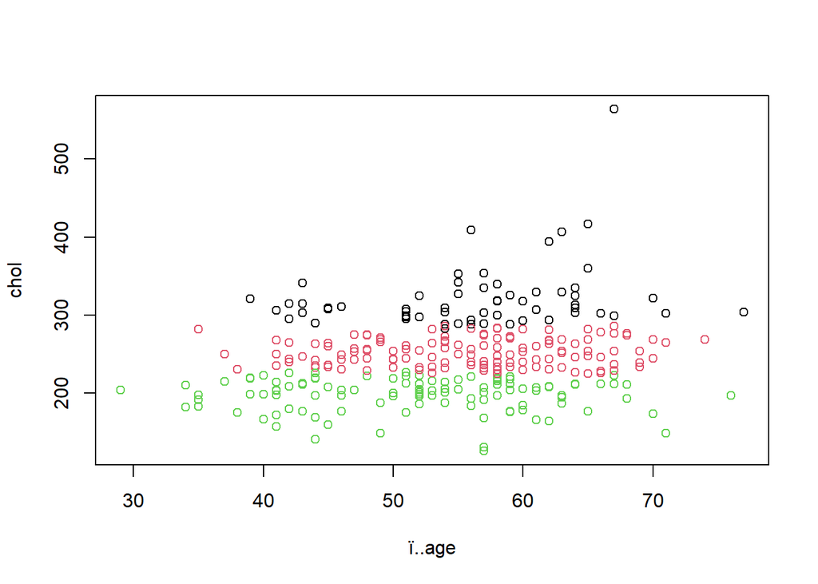

```r
plot(hd_data.new[, c(1,5)], col=result_hd$cluster) #menampilkan hasil klustering antara umur dan kolestrol.
```

##### Visualisasi menggunakan `ggplot2`

- Baris ke-1 memanggil library ggplot
- Baris ke-2 menjadikan tipe data `cluster` dari numerik ke diskret (kategori/factor)
- Baris ke-3 membuat center klustering
- Baris ke-4 dan seterusnya menentukan datapoint sesuai dengan variabel yang diinginkan, menentukan ukuran center radius, dan ketebalan warnanya

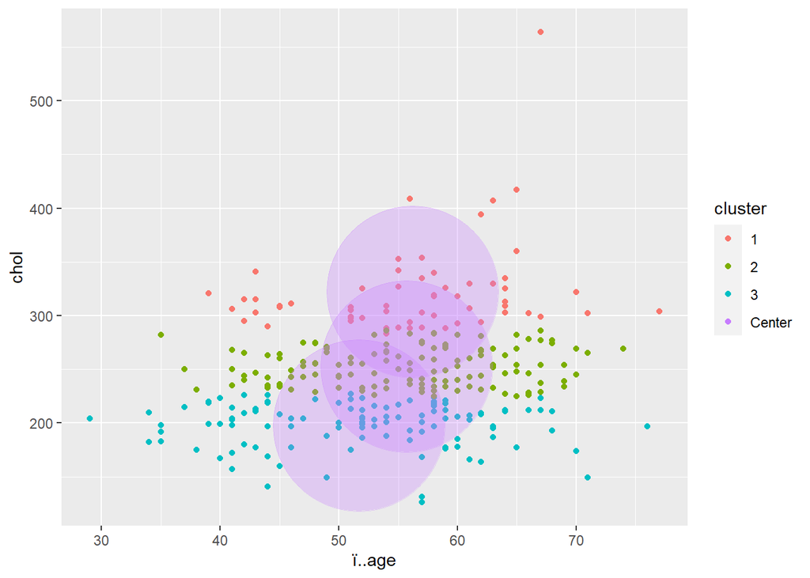

```r
library(ggplot2) #panggil library
hd_data.new$cluster <- factor(result_hd$cluster) #menjadikan tipe data `cluster` dari numerik ke diskret
centers <- as.data.frame(result_hd$centers) # membuat center klustering
ggplot() +
  geom_point(data=hd_data.new, aes(x=ï..age, y=chol,color=cluster))  +
  geom_point(data=centers, aes(x=ï..age, y=chol, color="Center"),
             size=50, alpha=.3, show.legend = FALSE)
```

**3. Melihat hasil Fungsi K-mean terhadap data set heart disease**

Untuk melihat nilai apa saja yang dikembalikan oleh fungsi `kmeans`, dapat dilihat melalui

```r
attributes(result_hd)$names
```

```
## [1] "cluster"      "centers"      "totss"        "withinss"     "tot.withinss"
## [6] "betweenss"    "size"         "iter"         "ifault"
```

dan untuk memanggil nilai di atas, dapat dilakukan dengan cara `result_hd$cluster`, `result_hd$size`, dan begitu seterusnya.

Kita bisa melihat berapa banyak data pada tiap kluster dengan menuliskan code seperti di bawah ini.

```r
result_hd$size # Untuk melihat berapa banyak data point pada tiap kluster
```

```
## [1]  60 133 110
```

Nah Untuk mengevaluasi **cost** kita bisa menggunakan function yang disebut **distortion** function dengan menuliskan kode dibawah ini.

```r
result_hd$tot.withinss ## Untuk melihat nilai distortion (jumlah perbedaan jarak data point dengan centroid) pada iterasi terakhir.
```

```
## [1] 470883.8
```

**4. kesimpulan hasil clustering**

Berdasarkan hasil klustering diatas, dapat kami simpulkan bahwa:

1. Lebih banyak orang yang kolestrolnya diatas 300mg/dl pada umur diatas 50 tahun
2. Kluster-1, merupakan kelompok orang yang tingkat kolestrolnya sangat tinggi (diatas 300mg/dl)
3. Kluster-2, merupakan kelompok orang yang tingkat kolestrolnya cukup tinggi (200mg/dl-300mg/dl)
4. Kluster-3, merupakan kelompok orang yang tingkat kolestrolnya rendah (dibawah 200mg/dl)

Menurut jurnal ilmiah “Cholesterol and Coronary Heart Disease: Predicting Risks by Levels and Ratios” oleh Bruce Kinosian, menyatakan bahwa rasio kolesterol dapat digunakan sebagai ukuran untuk mempertimbangkan risiko penyakit jantung koroner dan tabel kadar kolestrol yang dibuat Jennifer Moll PharmD yang menyatakan bahwa kadar kolestrol diatas 240mg/dl memiliki tingkat resiko terkena penyakit jantung yang cukup tinggi karena kadar kolestrol yang tiggi dapat menyumbat pembuluh jantung.

Maka dapat dikatakan bahwa pada umur berapapun jika kadar kolestrol dibawah 200 mg/dl maka resiko terkena penyakit jantung lebih rendah, dibanding mereka yang kadar kolestrolnya antara 200mg/dl-300mg/dl. Jika kadar kolestrolnya lebih dari 300mg/dl resiko terkena penyakit jantung bisa dibilang cukup tinggi.

**5. Referensi**

- Kinosian, B., Glick, H., & Garland, G. (1994). Cholesterol and coronary heart disease: predicting risks by levels and ratios. Annals of internal medicine, 121(9), 641-647.
- https://www.verywellhealth.com/do-i-really-need-to-worry-about-my-high-cholesterol-698283.
- https://www.webmd.com/heart-disease/guide/heart-disease-lower-cholesterol-risk#1.
- Tutorial K-Means by FSD team